# Exploring Data on Prosperous Loans

## Overview of the survey

In this survey, we wanted to understand two things:

- Factors that can be used to predict credit default.
- What factors influence the prosperity rating.

## Dataset Preview

This dataset contains 113937 loans with 81 variables on each loan, for the purpose of this survey we considered the following variables: Term, LoanStatus, BorrowerRate, ProsperRating (Alpha), ListingCategory (numeric), EmploymentStatus, DelinquenciesLast7Years, StatedMonthlyIncome, TotalProsperLoans , LoanOriginalAmount, LoanOriginationDate, Recommendations, Investors.

### Employment status

**Finding 2:**

- The majority of borrowers are employed and all other categories represent a small portion of borrowers.
- In a small group, full time is the highest, after which the freelancers are there and so on.

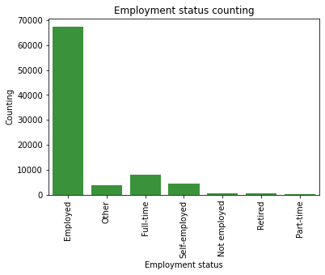

### Prosperity rating and employment status

**Finding 5:**

- The lower coasts seem to have larger proportions of people with the employment status "Not employed", "Self-employed", "Retired" and "Part-time".

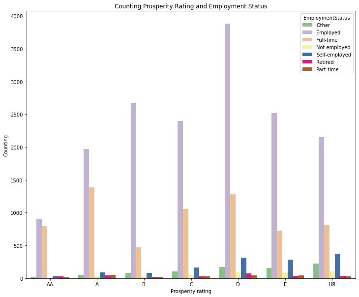

### Loan amount and employment status

**Finding 6:**

- From the following graph, we can tell that "employees" tend to take the largest loan amounts

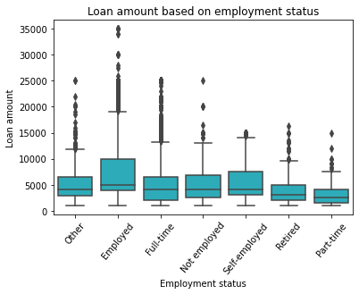

### Rating, loan amount and loan status

**Finding 1:**

- With the exception of the lowest ratings, defaulted credits tend to be larger than completed credits.
- Most defaulted loans come from people with low prosperity ratings.

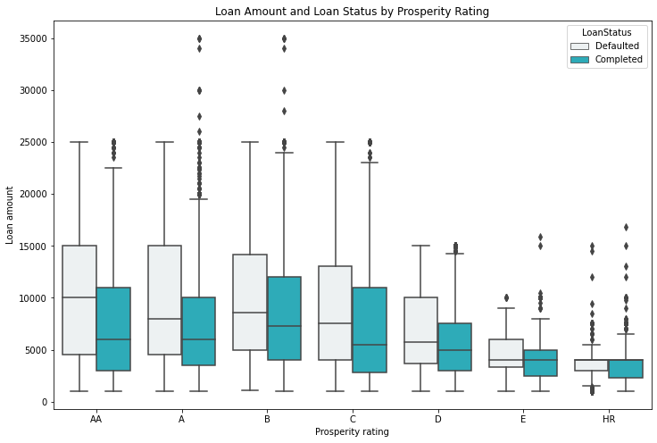

### Rating, loan amount and employment status

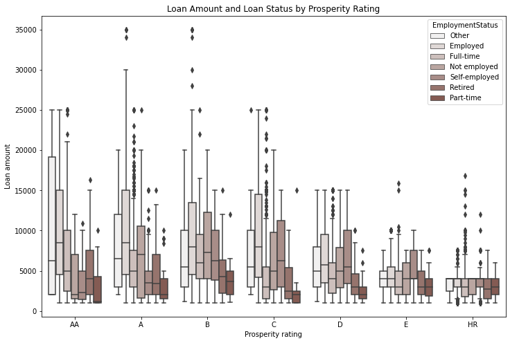